# VG_Chartz_analysis

Brennan Donnell

12/15/2018

[Shinyapp.io](https://bjn82.shinyapps.io/VG_Sales/)

I’ve picked the [Video Games sales dataset](https://www.kaggle.com/gregorut/videogamesales).

Reason: I like video games, particularly old systems. It interests me to see how the technology has shifted. The rise and fall of developers such as Sega, the flaws and features of consoles, and more.

```r
library(dplyr)
library(stringr)
library(rebus)
library(data.table)
library(ggplot2)
library(lubridate)
library(plotly)
library(markdown)
library(shiny)
```

After loading in the necessary libraries, I then read in the data through `fread` and converted it to a tibble.

```r
df <- tbl_df(fread('vgsales.csv',
                     header=T,
                     fill=TRUE,
                     sep=","))
```

Once the data is read into the tibble, named *df*, I analyzed the data to see if there were any missing values.

```r
colSums(is.na(df))
```

```
##         Rank         Name     Platform         Year        Genre
##            0            0            0            0            0
##    Publisher     NA_Sales     EU_Sales     JP_Sales  Other_Sales
##            0            0            0            0            0
## Global_Sales
##            0
```

No missing values in sight! Amazing! But, let’s make certain of it by searching for string values of *N/A*.

```r
for (col in 1:length(df)) {
  na_count <- sum(df[col] == 'N/A' )
  unknown_count <-sum(df[col] == 'Unknown' )
  ifelse(na_count ==0, NA, print(str_c(names(df[col]), ': ', na_count," values of 'N/A'")))
  ifelse(unknown_count ==0, NA, print(str_c(names(df[col]), ': ', unknown_count," values of 'Unknown'")))
}
```

```
## [1] "Year: 271 values of 'N/A'"
## [1] "Publisher: 58 values of 'N/A'"
## [1] "Publisher: 203 values of 'Unknown'"
```

So despite there being no *NA* values, there are still some missing values. First thing to do is to remove NAs for columns. While there could be many reasons for the year missing, it could likely be due to * not being released as of when the data was published * A game that was cancelled

Also, to look at games where there is either no info about a publisher or the publisher is unknown.

```r
df_filt <- df %>%
  filter(Year != 'N/A') %>%
  filter(Publisher != 'N/A')%>%
  filter(Publisher!= 'Unknown')

df_filt$Year <- as.numeric(df_filt$Year)
df_filt <- df_filt %>%
  filter(Year <= year(Sys.Date()))

rm(df)

region_sales <- 7:11
names(region_sales) <- names(df_filt[7:11])
```

```r
df_plat <- df_filt %>%
  group_by(Platform) %>%
  summarise(n=n())


top_sales <- function(vg_sys){
  df_vg <- df_filt %>%
    filter(Platform == vg_sys) %>%
    arrange(Rank)
  return(head(df_vg, n = 10))
}
```

The purpose of this part is to show how many games in the chart corresponded to a given genre for all platforms. It was my dad’s idea, and as the chunk is named, a last minute idea.

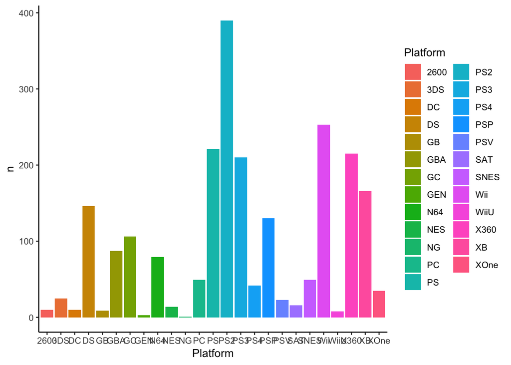

```r
df_genre <- df_filt %>%
  filter(Genre == 'Sports') %>%
  group_by(Platform) %>%
  summarise(n=n())

ggplot(data = df_genre, aes(x=Platform, y=n, fill = Platform)) + geom_col() + theme_classic()
```

```r
ui_full <- navbarPage(
  title = "Video Games",
  tabPanel(title = "Readme",
           includeMarkdown("readme.md")
  ),
  tabPanel(title = "Scatterplot",
           sidebarLayout(
             sidebarPanel(
               radioButtons(
                 inputId = "region_ui",
                 label = "Select Region",
                 choices = names(region_sales),
                 selected = names(region_sales[1]),
                 inline = TRUE),
               selectInput(
                 inputId = "series_ui",
                 label = "Select Series",
                 choices = unique(df_filt$Series),
                 selected = unique(df_filt$Series)[2])
             ),
             mainPanel(
               h2(str_c("Scatterplot of Global Sales by Platform",
                        " for a given series")),
               plotlyOutput(outputId = "scatter")
             )
           )
  ),
  tabPanel(title = "Publisher Sales Chart",
           sidebarLayout(
             sidebarPanel(
               selectInput(
                 inputId = "publisher_ui",
                 label = "Select Publisher",
                 choices = unique(df_filt$Publisher),
                 selected = unique(df_filt$Publisher)[1])
             ),
             mainPanel(
               h2("Barchart of frequency of genre for a given publisher"),
               plotOutput(outputId = "bar")
             )
           )
  ),
  tabPanel(title = "Console Sales Table",
           sidebarLayout(
             sidebarPanel(
               sliderInput(
                 inputId = "range",
                 label = "Year range",
                 min = min(df_filt$Year),
                 max = max(df_filt$Year),
                 value = c(1995, 2005),
                 sep = ""
               )
             ),
             mainPanel(
               h2("Console game sales throughout the years"),
               splitLayout(
                 tableOutput(outputId = "table"),
                 plotOutput(outputId = "table_bar"))))
  ),
  tabPanel(title = 'Sales by Genre',
           sidebarLayout(
             sidebarPanel(
               selectInput(
                 inputId = 'gen',
                 label = "Select Genre",
                 choices = unique(df_filt$Genre),
                 selected = unique(df_filt$Genre)[1]
               )
             ),
             mainPanel(
               h2("Plot of genre sales by platform"),
               plotOutput(
                 outputId = 'gen_bar'
               )
             )
           )
  ),
  tabPanel(title = "Facts",
           sidebarLayout(
             sidebarPanel(
               selectInput(
                 inputId = "sys",
                 label = "Select System",
                 choices = unique(df_filt$Platform))
             ),
             mainPanel(
               tabsetPanel(
                 tabPanel(title = "Facts & Info",
                          splitLayout(
                            imageOutput(outputId = "img"),
                            htmlOutput(outputId = "txt")
                          )
                 ),
                 tabPanel(title = "Table",
                          tableOutput(outputId = "tbl")
                          )
                 )
               )
             )
           )
)


server_full <- function(input, output){
  filtered_data_1 <- reactive({
    filter(
      df_filt,
      Series == input$series_ui)})
  filtered_data_2 <- reactive({
    as.data.frame(table(filter(
      df_filt,
      Publisher == input$publisher_ui)$Genre))})
  filtered_data_3 <- reactive({
    filter(
      df_filt,
      Year >= min(input$range) & Year <= max(input$range))})
  filtered_data_4 <- reactive({top_sales(input$sys)})
  filtered_data_5 <- reactive({
    df_out <- df_filt %>%
      filter(Genre == input$gen) %>%
      group_by(Platform) %>%
      summarise(n=n())
    df_out
  })
  filtered_text <- reactive(input$sys)
  output$scatter <- renderPlotly({
    ggplotly(
      ggplot(
        filtered_data_1(),
        aes_string(
          x = "Platform",
          y = input$region_ui)) +
        geom_point(aes(colour = Genre, text=Name)) +
        theme_classic() +
        theme(axis.text.x = element_text(angle = 60, hjust = 1)))}
  )
  output$bar <- renderPlot({
    ggplot(
      data = filtered_data_2(),
      aes(
        x = Var1,
        y = Freq,
        fill = Var1)) +
      geom_col() +
      labs(
        title = names(input$publisher_ui),
        x = "Genre",
        y = "Frequency") +
      scale_fill_hue(h = c(0,360)) +
      theme_classic() +
      theme(axis.text.x = element_text(angle = 60, hjust = 1))}
  )
  output$gen_bar <- renderPlot({
    ggplot(
      data = filtered_data_5(),
      aes(
        x = Platform,
        y = n,
        fill = Platform,
      )
    ) +
      geom_col() +
      labs(x = "System", y = "Games") +
        scale_fill_hue(h = c(0,360)) +
        theme_classic() +
        theme(axis.text.x = element_text(angle = 60, hjust = 1))
  })
  output$table <- renderTable(
    {
      tb <- filtered_data_3() %>%
        group_by(Platform) %>%
        summarise(NA_Sales = n()) %>%
        arrange(desc(NA_Sales))
      tb
    },
    striped = TRUE,
    hover = TRUE
  )
  output$table_bar <- renderPlot(
    {
      ggplot(
        data = filtered_data_3(),
        aes(
          x = Platform,
          y = NA_Sales,
          fill = Platform)
      ) +
        geom_col() +
        labs(x = "System", y = "Sales") +
        scale_fill_hue(h = c(0,360)) +
        theme_classic() +
        theme(axis.text.x = element_text(angle = 60, hjust = 1))
    }
  )
  output$img <- renderImage({
    filename <- normalizePath(file.path('./www',
                                        str_c(filtered_text(),'.jpg')))

    # Return a list containining the filename
    list(src = filename)
  },deleteFile = FALSE )
  output$txt <- renderText(
    includeMarkdown(
      str_c('Systems/',filtered_text(),'.md')))
  output$tbl <- renderTable(
    {filtered_data_4()},
    striped = TRUE,
    hover = TRUE
  )
}

shinyApp(ui = ui_full, server = server_full)
```

Shiny applications not supported in static R Markdown documents

## Insights from the project?

1. Games that came bundled with systems or accessories were generally the top-selling games for that platform
- e.g.: *Wii Sports* & *Kinect Adventures*.
2. Not all systems had a top ten. And some systems that were included in the data were never released in North America
- e.g.: the WonderSwan, TG16.
3. Certain publishers tended to put out more of certain types of games, though there is a logical explanation to it.
- Electronic Arts puts out a lot of sports games, although they hold the licenses to many yearly sports games such as *Madden*.
- SquareSoft (Now Square Enix) and Atlus put out primarily JRPGs
4. *Minecraft* for the PS Vita (PSV) was the top-selling PS Vita game, selling more units in Japan and Europe than in North America.